# dsf2

M. Newbery & E. Bendall

1/03/2021

Markdown runs in chunks, makes it easier to compartmentalise operations and structure script. Knitting the document with knitr outputs word document

```r
knitr::opts_chunk$set(echo = TRUE, fig.width=8, fig.height=6)

library(here)
library(dplyr)
library(ggplot2)
library(mgcv)
library(readxl)
library(stringr)
library(tidyr)
library(bayesplot)
library(rstan)
library(brms)
library(tidybayes)
library(RColorBrewer)
library(car)
###### Some helper functions courtesy of Michael Bedward #####


#These options help Stan run faster (Stan is the machinery under the hood of brms):

rstan_options(auto_write = TRUE)
options(mc.cores = parallel::detectCores())

# Make sure the scales package is available (it should be if ggplot is installed)
requireNamespace("scales")

# Default graph theme - white background
theme_set( theme_bw() )

set.seed(42)


# Set to TRUE to force models to be refitted
REFIT_MODELS <- TRUE


# Create a folder for fitted models if one does not already exist
FittedModelsPath <- here("fitted_models")
if (!dir.exists(FittedModelsPath)) {
  dir.create(FittedModelsPath)
}


# Load brms if it is installed (requires Stan software and the rstan package).
# If not installed, HAS_BRMS will be set to FALSE.
HAS_BRMS <- suppressWarnings(
  require("brms", quietly = TRUE)
)


# Save a graph to a PDF file
gg_pdf <- function(plot, filename, size = pagesize("A4", "landscape", "cm")) {

  if (!inherits(size, "pagesize")) stop("The size argument should be a pagesize (list) object")

  ggsave(
    filename,
    plot,
    width = size$width,
    height = size$height,
    units = size$units)
}


# Calculate highest posterior density interval for a vector of values (e.g. calculate credible intervals)
hpdi.vec <- function (x, prob = 0.95) {
  n <- length(x)
  if (n <= 1) stop("x must have more than 1 element")
  x <- sort(x)

  gap <- max(1, min(n - 1, round(n * prob)))
  init <- 1:(n - gap)

  inds <- which.min(x[init + gap] - x[init])

  out <- c(lower = x[inds], upper = x[inds + gap])
  out
}
```

create dataframe and view column names

```r
dat.pre <- read.csv("epicormic_3.csv")

dat.pre
```

| Site | Severity.Class | bark | Species | circ | DBH | height | bark.1 | Location | Epicormic.Top.50 | Epicormic.Bottom.50 | Total.Epicormic | Vegetation.Formation | Bark.Type | X | X1 |
| --- | --- | --- | --- | --- | --- | --- | --- | --- | --- | --- | --- | --- | --- | --- | --- |
| 5POINT | Low | Rough | Corymbia gummifera | 114 | 36.287327 | 910 | 1.6 | 1 | 0.0 | 0.10 | 0.10 | WS | Rough | NA | 63 |
| 5POINT | Low | Rough | Corymbia gummifera | 50 | 15.915494 | 800 | 1.2 | 1 | 5.0 | 30.00 | 35.00 | WS | Rough | NA | 66 |
| 5POINT | Low | Rough | Corymbia gummifera | 50 | 15.915494 | 800 | 1.2 | 1 | 5.0 | 30.00 | 35.00 | WS | Rough | NA | 67 |
| 5POINT | Low | Rough | Corymbia gummifera | 18 | 5.729578 | 350 | 0.4 | 1 | 0.0 | 1.00 | 1.00 | WS | Rough | NA | 71 |
| 20CM | Mod | Rough | Corymbia gummifera | 26 | 8.276057 | 400 | 2.1 | 1 | 20.0 | 30.00 | 50.00 | DS | Rough | NA | 232 |
| 20CM | Mod | Rough | Corymbia gummifera | 26 | 8.276057 | 400 | 2.1 | 1 | 0.0 | 2.00 | 2.00 | DS | Rough | NA | 233 |
| 20CM | Mod | Rough | Corymbia gummifera | 26 | 8.276057 | 400 | 2.1 | 1 | 1.0 | 5.00 | 6.00 | DS | Rough | NA | 234 |
| 20CM | Mod | Rough | Corymbia gummifera | 26 | 8.276057 | 400 | 2.1 | 1 | 0.0 | 3.00 | 3.00 | DS | Rough | NA | 235 |
| 20CM | Mod | Rough | Corymbia gummifera | 26 | 8.276057 | 400 | 2.1 | 1 | 0.0 | 2.00 | 2.00 | DS | Rough | NA | 236 |
| 20CM | Mod | Rough | Corymbia gummifera | 26 | 8.276057 | 400 | 2.1 | 1 | 0.0 | 1.00 | 1.00 | DS | Rough | NA | 237 |

[output cut: 237 more lines]

select variables of interest and rename to whatever you want. Shorter is better

```r
dat.pre <- dat.pre %>%
  select(site = "Site",
         sev = "Severity.Class",
         spp = "Species",
         dbh = "DBH",
         loc = "Location",
         veg = "Vegetation.Formation",
         bark = "bark")


dat.pre
```

| site | sev | spp | dbh | loc | veg | bark |
| --- | --- | --- | --- | --- | --- | --- |
| 5POINT | Low | Corymbia gummifera | 36.287327 | 1 | WS | Rough |
| 5POINT | Low | Corymbia gummifera | 15.915494 | 1 | WS | Rough |
| 5POINT | Low | Corymbia gummifera | 15.915494 | 1 | WS | Rough |
| 5POINT | Low | Corymbia gummifera | 5.729578 | 1 | WS | Rough |
| 20CM | Mod | Corymbia gummifera | 8.276057 | 1 | DS | Rough |
| 20CM | Mod | Corymbia gummifera | 8.276057 | 1 | DS | Rough |
| 20CM | Mod | Corymbia gummifera | 8.276057 | 1 | DS | Rough |
| 20CM | Mod | Corymbia gummifera | 8.276057 | 1 | DS | Rough |
| 20CM | Mod | Corymbia gummifera | 8.276057 | 1 | DS | Rough |
| 20CM | Mod | Corymbia gummifera | 8.276057 | 1 | DS | Rough |

[output cut: 237 more lines]

quick way to check what levels are in your factors

```r
dat.pre %>%
  distinct(sev, veg, loc, site)
```

| site | sev | loc | veg |
| --- | --- | --- | --- |
| 5POINT | Low | 1 | WS |
| 20CM | Mod | 1 | DS |
| 35BTC | Ext | 1 | WS |
| 32BTC | Ext | 1 | DS |
| 12MOD | Mod | 1 | DS |
| 16BTC | Low | 1 | WS |
| 901MOD | Mod | 1 | DS |
| 2423MOD | Mod | 1 | WS |
| 20BTC | Mod | 1 | WS |
| 6EXT | Ext | 1 | WS |

[output cut: 22 more lines]

Set up factor labels and make everything lower case. your response variable in this example is an ordered categorical varibale so here we tell R that

```r
dat.epi <- dat.pre %>%
  mutate(sev = factor(sev, levels = c("Low", "Mod",  "Ext"),
                           labels = c("Low", "Mod",  "High"))) %>%

  mutate(loc = factor(loc,levels = c("0",    "1"),
                           labels = c("Canopy", "No-Canopy"))) %>%

  mutate(veg = factor(veg, levels = c("DS", "WS"),
                           labels = c("dsf", "wsf"))) %>%

  ## sorry for the messy code here but just grouping the species, there are better ways to do this
     mutate(group = factor(spp, levels = c("Eucalyptus globoidea",
                                           "Eucalyptus muelleriana",
                                           "Eucalyptus agglomerata",
                                           "Corymbia gummifera",
                                           "Eucalyptus sieberi",
                                           "Eucalyptus fastigata",
                                           "Eucalyptus viminalis",
                                           "Eucalyptus paniculata",
                                           "Eucalyptus cypellocarpa",
                                           "Eucalyptus radiata",
                                           "Eucalyptus rubida",
                                           "Eucalyptus consideniana",
                                           "Eucalyptus globulus subsp. maidenii"),
                                labels = c("Present",
                                           "Present",
                                           "Present",
                                           "Present",
                                           "Absent",
                                           "Absent",
                                           "Absent",
                                           "Present",
                                           "Absent",
                                           "Absent",
                                           "Absent",
                                           "Absent",
                                           "Absent"))) %>%
  mutate(site = factor(site)) %>%

  ## remove species from dataframe not needed anymore
    select(-(spp))
```

## round dbh values to assist with modelling later. This is acceptable enough

```r
dat.epi$dbh <- round(dat.epi$dbh, digits = 1)
```

Check for missing values

```r
colSums( is.na(dat.epi) )
```

```
##  site   sev   dbh   loc   veg  bark group
##     0     0     0     0     0     0     0
```

There are no missing values

Now a quick tabular look at the data

```r
with(dat.epi, table(sev, loc))
```

```
##       loc
## sev    Canopy No-Canopy
##   Low      16        27
##   Mod      63        46
##   High     46        49
```

```r
with(dat.epi, table(veg, loc, sev))
```

```
## , , sev = Low
##
##      loc
## veg   Canopy No-Canopy
##   dsf      0         0
##   wsf     16        27
##
## , , sev = Mod
##
##      loc
## veg   Canopy No-Canopy
##   dsf     51        32
##   wsf     12        14
##
## , , sev = High
##
##      loc
## veg   Canopy No-Canopy
##   dsf     23        29
##   wsf     23        20
```

overall summary of data

```r
summary(dat.epi)
```

```
##       site       sev           dbh                loc       veg
##  2345MOD: 32   Low : 43   Min.   :  4.50   Canopy   :125   dsf:135
##  20CM   : 29   Mod :109   1st Qu.: 17.50   No-Canopy:122   wsf:112
##  24BTC  : 27   High: 95   Median : 38.20
##  32BTC  : 25              Mean   : 40.02
##  2423MOD: 17              3rd Qu.: 54.10
##  35BTC  : 15              Max.   :108.20
##  (Other):102
##       bark         group
##  Fibrous:130   Present: 90
##  Rough  :116   Absent :157
##  Smooth :  1
##
##
##
##
```

have a look at dbh relationship with resprouting location

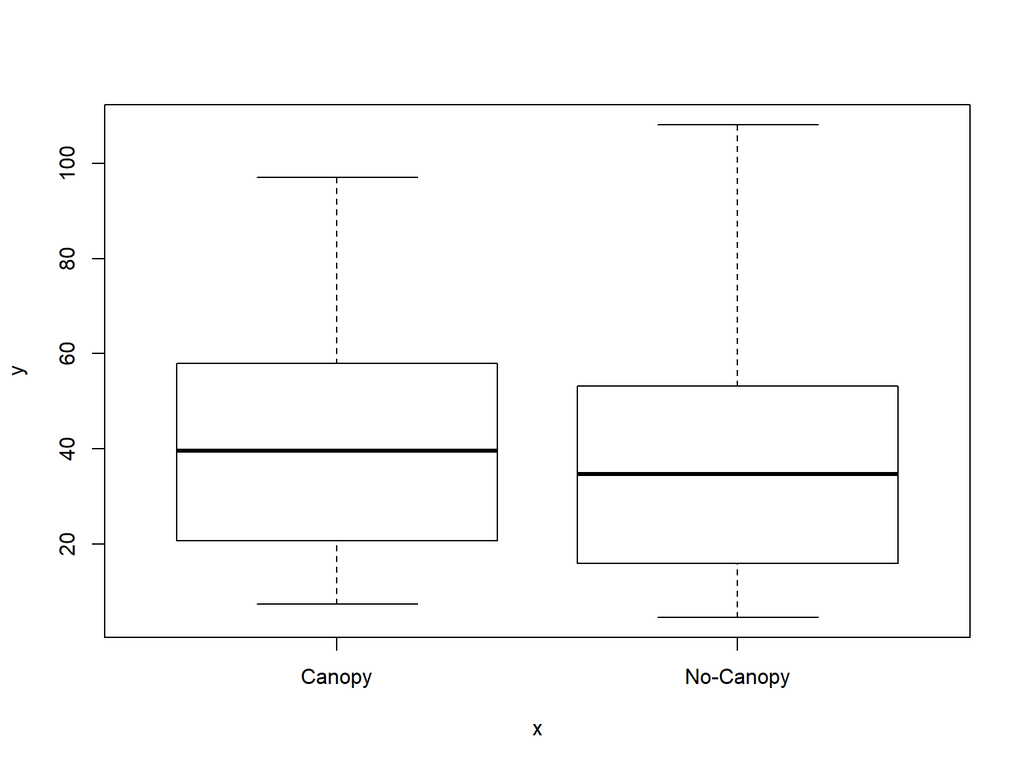

```r
plot(dat.epi$loc, dat.epi$dbh)
```

This is the expected relationship

Heres a more informative look at the data

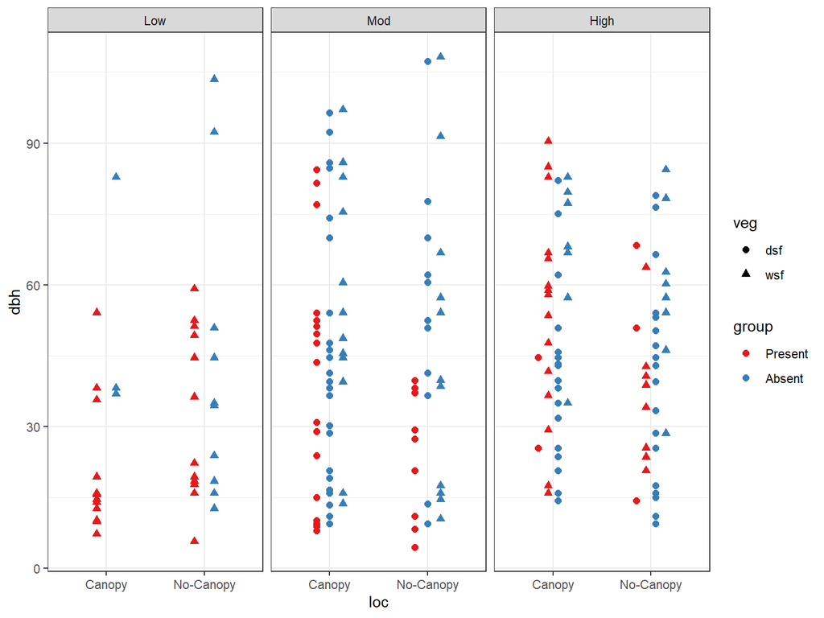

```r
ggplot(data = dat.epi, aes(x = loc)) +

  geom_point(aes(y = dbh, color = group, shape = veg),
             position = position_dodge(width = 0.4),
             size = 2) +

  scale_color_brewer(palette = "Set1") +

  facet_grid(~sev)
```

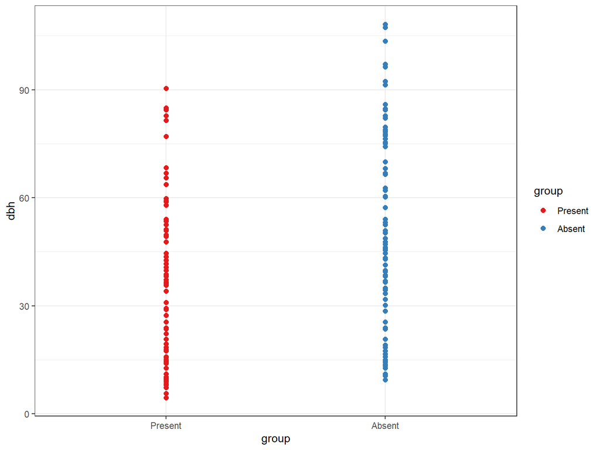

```r
ggplot(data = dat.epi, aes(x = group)) +

  geom_point(aes(y = dbh, color = group),
             position = position_dodge(width = 0.4),
             size = 2) +

  scale_color_brewer(palette = "Set1")
```

```r
save(dat.epi, file = "prelim.canopy.data")
```